# Zadání projektu

[figure not shown]

Hydrologické modelování dopadů klimatické změny

Martin Hanel & Adam Vizina

## Zadání projektu

> **Pro vybrané povodí zjistěte očekávané změny hydrologické bilance v měsíšním kroku a vyhodnoťte účinek opatření v podobě zvýšení/snížení retence půdy o 50 % na ukazatele hydrologického sucha**.
- pro ulehčení projektu byl vytvořen balík `KZ2020`, který obsahuje veškerá data potřebná pro zpracování projektu
- balík je možno stáhnout ZDE
- toto zadání je přístupné zároveň po nainstalování balíku KZ2020 příkazem `vignette("Projekt", package="KZ2020")`

## Upřesnění

Modelování dopadů změny klimatu probíhá podle následujícího schematu:

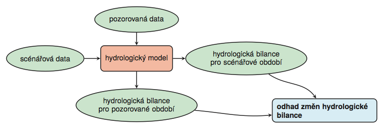

Stručně řečeno: pomocí pozorovaných dat (srážky, teplota a odtok) nakalibrujeme parametry hydrologického modelu Bilan, vytvoříme scénářová data reprezentující budoucí klima a pomocí modelu Bilan s již nakalibrovanými parametry simulujeme budoucí hydrologickou bilanci. Pokud chceme zjistit vliv změny retence půdy na hydrologickou bilanci, musíme změnit jeden z parametrů modelu Bilan a simulaci opakovat.

Z toho vyplývá následující struktura činností:

1. Výběr povodí a získání pozorovaných dat
2. Kalibrace hydrologického modelu a její vyhodnocení
3. Tvorba scénářových řad srážek a teploty
4. Simulace budoucí hydrologické bilance s a bez opatření
5. Vyhodnocení ukazatelů sucha

Následující text je dle tohoto dělení členěn. Postup hydrologického modelování dopadů změny klimatu je více rozveden [např. zde](https://mediasite.czu.cz/Mediasite/Play/b246014081574610bdf8a1f29a9ec1d11d).

Výstupem cvičení bude stručný protokol psaný v Rmarkdownu (bylo probíráno na cvičení). Šablona protokolu je dostupná ZDE. Informace o využití RMarkdownu jsou uvedeny [např. zde](https://rmarkdown.rstudio.com/). Protokoly je možné vypracovávat ve dvojicích.

**Protokol bude odevzdán jako html dokument přes modul na Moodle - jiné formy odevzdávání nejsou akceptovány.**

## 1. Výběr povodí a data

Po náhrání balíku `KZ2020`

```r
> library(KZ2020)
```

je možné zobrazit zahrnuté datasety pomocí

```r
> data(package="KZ2020")
```

Dataset nahrajeme pomocí `data(NAZEV DATASETU)`, jednotlivé datasety jsou dokumentované, viz např.

```r
> data("povodi")
> ?povodi
#  Rendering development documentation for 'povodi'
```

### 1.1 Výběr povodí

Dataset `povodi` je prostorový objekt třídy `SpatialPolygonsDataFrame`. Využijeme následující funkce:

- `plot` pro vykreslení povodí
- `povodi@data` pro zobrazení atributové tabulky
- `povodi[i, ]` pro zobrazení `i`tého prvku

Vyberu povodí na základě vybraného `DBCN` (např. 345000) a uložím ho do nové proměnné `mojePov`:

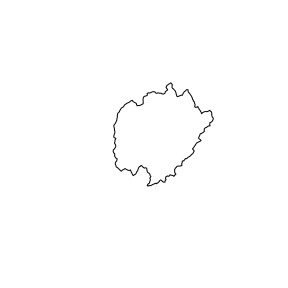

```r
> ## povodi@data
> mojePov = povodi[povodi$DBCN == 345000, ]
> plot(mojePov)
```

Interaktivní mapu je možno zobrazit (a následně uložit výřez v RStudiu) pomocí balíku `leaflet`.

```r
> library(leaflet)
> leaflet(mojePov) %>% addTiles(urlTemplate = 'https://{s}.tile.opentopomap.org/{z}/{x}/{y}.png') %>% addPolygons()
```

[interactive chart not shown]

### 1.2 Získání dat pro kalibraci modelu Bilan

Hydrometeorologická data jsou opět obsažena v balíku KZ2020 - dataset `hydrometeo`. Jedná se o `data.table` (tabulku), struktura je popsána v nápovědě k datasetu, tj.

```r
> data("hydrometeo")
> ?hydrometeo
#  Rendering development documentation for 'hydrometeo'
```

Práce s `data.table` byla probírána na cvičení, popis základních fukcí je uveden na moodlu v sekci data.table. Pro další práci potřebujeme vybrat data pro stejné povodí, pro které jsme vybrali rozvodnici (zde DBCN=345000).

```r
> dta = hydrometeo[DBCN == 345000, ]
> dta
#           DBCN      AREA        DTM    Q          P          T        R
#      1: 345000 351184410 1961-01-01 4.94 0.49655172 -2.2079362 1.215361
#      2: 345000 351184410 1961-01-02 4.94 0.02586207 -2.0958672 1.215361
#      3: 345000 351184410 1961-01-03 4.72 0.00862069 -1.1510397 1.161236
#      4: 345000 351184410 1961-01-04 4.94 1.75000005  0.1713741 1.215361
#      5: 345000 351184410 1961-01-05 4.72 1.75517237 -0.6562121 1.161236
#     ---
#  18197: 345000 351184410 2010-10-27 4.29 0.00000000 -0.3148328 1.055445
#  18198: 345000 351184410 2010-10-28 4.21 0.00000000  1.4903397 1.035764
#  18199: 345000 351184410 2010-10-29 4.13 0.00000000  3.9127533 1.016082
#  18200: 345000 351184410 2010-10-30 4.08 0.00000000  4.5110291 1.003780
#  18201: 345000 351184410 2010-10-31 4.13 0.00000000  7.7075806 1.016082
```

Výhodou data.tablu je možnost efektivně provádět operace po skupinách dat. Typickým příkladem je agregace data z denního kroku do měsíčního (potřebujeme pro model Bilan). Provedeme následovně:

```r
> dta = dta[, .(DTM = DTM[1], Q = mean(Q), P = sum(P), T = mean(T), R = sum(R)), by = .(year(DTM), month(DTM))]
> dta
#       year month        DTM         Q         P          T        R
#    1: 1961     1 1961-01-01  3.853548  28.16897 -5.0017071 29.39010
#    2: 1961     2 1961-02-01  4.084286  35.40862 -0.8491924 28.13537
#    3: 1961     3 1961-03-01  8.875161  73.96034  2.6936767 67.68875
#    4: 1961     4 1961-04-01 11.040667  47.42931  8.2710293 81.48826
#    5: 1961     5 1961-05-01  5.533548  84.51897  7.9284931 42.20306
#   ---
#  594: 2010     6 2010-06-01 11.160667  58.29655 14.8883856 82.37395
#  595: 2010     7 2010-07-01  4.686129 131.31552 17.5685932 35.73999
#  596: 2010     8 2010-08-01  4.401935 159.04828 15.0260460 33.57252
#  597: 2010     9 2010-09-01 10.632667 131.90000  9.1283856 78.47692
#  598: 2010    10 2010-10-01  6.566129  17.37586  4.4489047 50.07831
```

Data.table je rovněž efektivní z hlediska zápisu. Pro vykreslení základních veličin můžeme např. psát:

[figure not shown]

```
#  NULL
> dta[, plot(DTM, P, type = 'l')]
```

[figure not shown]

```
#  NULL
```

```r
> par(mar = c(3, 3, 1, 1), mgp = c(1.5, .5, 0))
> dta[, plot(DTM, T, type = 'l')]
```

Základní statistické charakteristiky dat je možné zobrazit následovně:

```r
> summary(dta)
#        year          month             DTM                   Q
#   Min.   :1961   Min.   : 1.000   Min.   :1961-01-01   Min.   : 1.329
#   1st Qu.:1973   1st Qu.: 3.250   1st Qu.:1973-06-08   1st Qu.: 3.521
#   Median :1985   Median : 6.000   Median :1985-11-16   Median : 5.074
#   Mean   :1985   Mean   : 6.483   Mean   :1985-11-15   Mean   : 6.500
#   3rd Qu.:1998   3rd Qu.: 9.000   3rd Qu.:1998-04-23   3rd Qu.: 8.002
#   Max.   :2010   Max.   :12.000   Max.   :2010-10-01   Max.   :46.600
#         P                 T                  R
#   Min.   :  3.969   Min.   :-10.4841   Min.   :  9.152
#   1st Qu.: 47.504   1st Qu.: -0.6815   1st Qu.: 26.242
#   Median : 68.765   Median :  5.7874   Median : 38.259
#   Mean   : 77.361   Mean   :  5.6300   Mean   : 48.674
#   3rd Qu.:100.176   3rd Qu.: 12.3389   3rd Qu.: 60.168
#   Max.   :426.310   Max.   : 19.6799   Max.   :355.407
```

Další tipy: - informačně přínosným grafem může být i např. boxplot - pro jednotlivé měsíce (a různé veličiny) např. `dta[, boxplot(T ~ month)]` - dalším užitečným grafem je histogram - např. `dta[, hist(P)]` nebo pro jednotlivé měsíce `par(mfrow = c(3, 4)); dta[, .(hist(P)), by = month]` - efektní je i využití balíku `ggplot2` - např.

```r
> ggplot(dta) + geom_histogram(aes(x = P)) + facet_wrap(~month)
```

## 2. Kalibrace hydrologického modelu

Práci s modelem Bilan v R přibližuje [tento tutorial](https://mediasite.czu.cz/Mediasite/Play/651d0d96c7254149a5ccdd3545293f791d).

### Model Bilan

Manuál modelu je ke stažení [zde](http://bilan.vuv.cz/bilan/wp-content/uploads/2015/03/bilan_man_cs_2015-06-23.pdf). Soubor k instalaci je v adresáři bilan. Soubor je nutné stáhnout a nainstalovat.

V Rku vytvoříme novou instanci modelu Bilan pomocí funkce `bil.new`

```r
> library(bilan)
#  Loading required package: Rcpp
> args(bil.new)
#  function (type, file = NULL, use_data = TRUE, data = NULL, modif = "none",
#      period = 0, ...)
#  NULL
```

kde `type` určuje typ modelu (`m` - měsíční, `d` - denní), `file` umožňuje vytvořit model na základě **výstupního** souboru z modelu Bilan, `data` umožňuje vytvořit model na základě **vstupního** souboru do modelu Bilan.

```r
> b = bil.new(type='m', data = dta[!is.na(R)])
#  Warning in evalq((function (..., call. = TRUE, immediate. = FALSE, noBreaks. = FALSE, : Unknown variable 'year'. Omitted.
#  Warning in evalq((function (..., call. = TRUE, immediate. = FALSE, noBreaks. = FALSE, : Unknown variable 'month'. Omitted.
#  Warning in evalq((function (..., call. = TRUE, immediate. = FALSE, noBreaks. = FALSE, : Unknown variable 'Q'. Omitted.
```

Optimalizace parametrů je možná pomocí příkazu `bil.optimize`, nicméně nejdříve je nutné odhadnout evapotranspiraci pomocí funkce `bil.pet`.

```r
> bil.pet(b)
> res = bil.optimize(b)
> head(res)
#            DTM         P        R       RM       BF  B         I           DR
#  1: 1961-01-01  28.16897 29.39010 16.02787 13.13729 NA  2.890578  0.000000000
#  2: 1961-02-01  35.40862 28.13537 19.92155 13.02764 NA  6.893913  0.000000000
#  3: 1961-03-01  73.96034 67.68875 45.30712 17.57550 NA 27.731622  0.000000000
#  4: 1961-04-01  47.42931 81.48826 23.21910 20.35385 NA  0.000000  2.865241961
#  5: 1961-05-01  84.51897 42.20306 18.71266 15.00596 NA  3.704548  0.002142398
#  6: 1961-06-01 125.16896 43.63000 36.51128 15.54353 NA  1.012326 19.955426418
#           PET        ET           SW        SS       GS       INF      PERC
#  1:  0.000000  0.000000 0.8050997104 12.558416 49.58268  15.61055 15.610549
#  2:  6.848317  6.848317 0.8050997104  3.888189 66.89166  37.23053 37.230530
#  3: 21.967112 21.967112 0.8050997104  0.000000 77.46596  55.88142 55.881422
#  4: 51.289833 45.368978 0.0001895718  0.000000 57.11210  44.56407  0.000000
#  5: 62.955465 62.955465 0.8050997104  0.000000 59.15804  84.51682 20.756448
#  6: 99.541512 99.541512 0.8050997104  0.000000 48.27421 105.21354  5.672026
#           RC          T  H WEI
#  1: 12.71997 -5.0017071 NA   1
#  2: 30.33662 -0.8491924 NA   1
#  3: 28.14980  2.6936767 NA   1
#  4:  0.00000  8.2710293 NA   1
#  5: 17.05190  7.9284931 NA   1
#  6:  4.65970 14.5800524 NA   1
```

Ve výše uvedeném případě jsme použili defaultní nastavení jak v případě funkce `bil.pet` (zde je možné nastavit způsob odhadu a jeho parametry - viz `?bil.pet`), tak i v případě `bil.optimize`. Parametry optimalizace je možné nastavit pomocí funkce `bil.set.optim`. Zejména můžeme ovlivnit

- metodu optimalizace - `method`
  - `BS` - půlení intervalu
  - `DE` - diferenciální evoluce
- kritéria optimalizace - `crit`
  - `MSE` - střední kvadratická chyba
  - `NS` - Nash-Sutcliffe
  - `LNNS` - log Nash-Sutcliffe
  - `MAPE` - střední procentuální chyba
  - `MAE` - střední absolutní chyba
- počet iterací `max_iter`

Nastavení parametrů kalibrace může vypadat např. následovně:

```r
> bil.set.optim(b, method = "DE")
> bil.set.params.lower(b, list(Spa = 20))
> res = bil.optimize(b)
```

Po provedení optimalizace můžeme zobrazit parametry pomocí příkazu `bil.get.params`:

```r
> bil.get.params(b)
#    name      current lower upper   initial
#  1  Spa 23.759365697    20 2e+02 1.477e+02
#  2  Dgw  5.541087229     0 2e+01 1.380e+01
#  3  Alf  0.001506825     0 3e-03 7.790e-04
#  4  Dgm 39.556245270     0 2e+02 1.522e+01
#  5  Soc  0.212006017     0 1e+00 6.990e-01
#  6  Wic  0.232385857     0 1e+00 3.420e-01
#  7  Mec  0.506716580     0 1e+00 7.990e-01
#  8  Grd  0.438210865     0 1e+00 4.990e-01
> bil.write.file(b, 'vystup.bil')
```

Parametry je rovněž možné načíst z Bilanovského výstupního souboru:

```r
>
> bil.read.params.file(b, 'vystup.bil')
> bil.get.params(b)
#    name     current lower upper     initial
#  1  Spa 23.75940000    20 2e+02 23.75940000
#  2  Dgw  5.54109000     0 2e+01  5.54109000
#  3  Alf  0.00150682     0 3e-03  0.00150682
#  4  Dgm 39.55620000     0 2e+02 39.55620000
#  5  Soc  0.21200600     0 1e+00  0.21200600
#  6  Wic  0.23238600     0 1e+00  0.23238600
#  7  Mec  0.50671700     0 1e+00  0.50671700
#  8  Grd  0.43821100     0 1e+00  0.43821100
```

### Vizuální vyhodnocení kalibrace

```r
> library(dygraphs)
>
> r = ts(res[, R], start = c(res[1, year(DTM)], res[1, month(DTM)]), frequency = 12 )
> rm = ts(res[, RM], start = c(res[1, year(DTM)], res[1, month(DTM)]), frequency = 12 )
> re = cbind(r, rm)
>
> dygraph(re) %>% dyRangeSelector() %>% dyRoller(rollPeriod = 1)
```

[interactive chart not shown]

### Kvantitativní vyhodnocení kalibrace

- možno použít balík `hydroGOF`
- např. `res[, hydroGOF::gof(RM, R)]`

## 3. Tvorba scénářových řad srážek a teploty

Pro tvorbu scénářových řad srážek a teploty použijeme jednoduchou přírůstkovou metodu. Přírůstková metoda je jednoduchý postup využívající informaci o změnách vybraných veličin v simulacích klimatických modelů k úpravě pozorovaných řad. Přírůstkové faktory jsou zpravidla odhadnuty pro jednotlivé měsíce porovnáním simulace klimatického modelu pro budoucí (např. 2070-2099) a kontrolní období (např. 1961-1990). V případě souborů klimatických modelů mohou být odhadnuty na základě změn rozdělení pravděpodobnosti pro jednotlivé veličiny mezi vybranými obdobími. Přírůstkové faktory pro teplotu ($\Delta T$) jsou odvozeny jako rozdíl průměrné teploty mezi budoucím a kontrolním obdobím, v případě srážek jsou přírůstkové faktory ($\Delta P$) vypočteny jako podíl průměrných srážek v budoucím a kontrolním období.

Scénářové řady pro jednotlivé veličiny jsou pak tvořeny úpravou pozorovaných řad příslušným způsobem (tj. přičtením pro teplotu a násobením pro srážky). Obecně lze analogicky postupovat i v případě jiných veličin simulovaných klimatickým modelem. Vždy je však třeba uvážit, do jaké míry jsou simulace dané veličiny realistické.

Pozorované řady srážek a teploty máme k dispozici v datasetu `hydrometeo`, z něj jsme vybrali data pro zvolené povodí a vložili je do proměnné `dta`. Rocvodnici povodí jsme uložili do proměnné `mojePov`. Změny měsíčních srážek a teploty jsou v proměnných `gcm_pr_ch` a `gcm_tas_ch` (viz nápověda k těmto datasetům). Jedná se o objekty třídy `RasterBrick` - tj. vícevrstvé rastrové objekty, kdy jednotlivé vrstvy odpovídají měsícům. Jednotlivé změny můžeme zobrazit např. pomocí

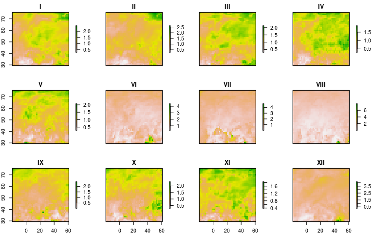

```r
> data("gcm_pr_ch")
> plot(gcm_pr_ch)
```

Jak lze vidět ze souřadnic, data jsou pro celou Evropu. Pro vyříznutí změn pro naše zájmové území (dle polygonu `mojePov`) použijeme

```r
> chp = extract(gcm_pr_ch, mojePov, fun = mean, weights = TRUE)
> chp
#              I       II      III      IV        V        VI       VII      VIII
#  [1,] 1.513707 1.089398 1.285919 1.26898 1.213702 0.8020651 0.4077726 0.3529718
#              IX        X       XI      XII
#  [1,] 0.6231461 1.009496 1.186182 1.188951
```

Pro naše povodí tedy lednové srážky rostou o `51.371` %, únorové o `8.94` %, atd. Podobně teplota:

```r
> data("gcm_tas_ch")
> cht = extract(gcm_tas_ch, mojePov, fun = mean, weights = TRUE)
> cht
#              I       II      III       IV        V      VI      VII     VIII
#  [1,] 6.693024 5.515289 5.017548 4.346802 5.138733 7.79306 9.979004 10.02884
#             IX        X       XI      XII
#  [1,] 8.643494 6.938049 4.857117 6.070831
```

roste v lednu o `6.693` °C, v únoru o `5.515` °C, atd.

Abychom mohli transformovat naše pozorovaná data pomocí těchto změn, musíme zahrnout vektory změn pro příslušné měsíce do datasetu `dta`. Vytvoříme tedy data.table se změnami

```r
> ch = data.table(month = 1:12, chp = chp[1, ], cht = cht[1, ])
```

a pomocí tzv. “fast join” připojíme k datasetu `dta`:

```r
> dta = ch[dta, on = 'month']
```

Syntaxe výše jednoduše říká, že napojuji dataset `ch` na dataset `dta` a společným klíčem je pole `month`. Změny srážek a teploty můžeme pochopitelně vykreslit např. pomocí

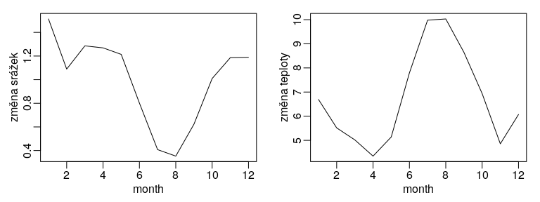

```
#  NULL
```

```r
> par(mfrow=c(1, 2), mgp = c(1.5, .5, 0), mar = c(3, 3, 1, 1))
> ch[, plot(month, chp, type = 'l', ylab = 'změna srážek')]
#  NULL
> ch[, plot(month, cht, type = 'l', ylab = 'změna teploty')]
```

Pak jen potřebujeme spočítat ovlivněnou řadu teplot a srážek - jednoduše tak, že současné srážky (`P`) přenásobíme přírůstkovým faktorem `chp`

```r
> dta[, futP := P * chp]
```

a k současné teplotě připočteme přírůstkový faktor pro teplotu `cht` :

```r
> dta[, futT := T + cht]
```

## 4. Simulace budoucí hydrologické bilance s a bez opatření

Nyní můžeme přikročit k simulaci hydrologické bilance dle zadání - celkově budeme mít 4 simulace:

- pro současný stav,
- pro podmínky ovlivněné změnou klimatu bez opatření,
- pro podmínky ovlivněné změnou klimatu s 50% zvýšením retence půdy,
- pro podmínky ovlivněné změnou klimatu s 50% snižením retence půdy.

Postup je ve všech případech obdobný:

- vytvoříme model (včetně nakalibrovaných paramterů - tj. použijeme funkci `bil.clone` na nakalibrovaný model nebo načteme parametry ze souboru)
- vložíme příslušná data
- pokud simuluje efekt opatření upravíme parametr `Spa`
- provedeme simulaci

### 4.1 Současný stav

Vytvoříme model:

```r
> b.ctrl = bil.clone(b)
```

nebo

```r
> b.ctrl = bil.new(type = "m", file = "vystup.bil")
```

spočteme potenciální evapotranspiraci a provedeme simulaci:

```r
> bil.pet(b.ctrl)
> res.ctrl = bil.run(b.ctrl)
```

### 4.2 Budoucí stav bez opatření

Vytvoříme model, vložíme data, spočítáme PET a provedeme simulaci:

```r
> b.fut = bil.clone(b)
> bil.set.values(b.fut, dta[, .(DTM, P = futP, T = futT)])
> bil.pet(b.fut)
> res.fut = bil.run(b.fut)
```

### 4.3 Budoucí stav s opatřeními

Vytvoříme model, upravíme parametry, spočítáme PET a provedeme simulaci:

Nejdříve snížení retence:

```r
> b.fut_dec = bil.clone(b.fut)
> pars = bil.get.params(b.fut_dec)
> pars
#    name     current lower upper     initial
#  1  Spa 23.75940000    20 2e+02 23.75940000
#  2  Dgw  5.54109000     0 2e+01  5.54109000
#  3  Alf  0.00150682     0 3e-03  0.00150682
#  4  Dgm 39.55620000     0 2e+02 39.55620000
#  5  Soc  0.21200600     0 1e+00  0.21200600
#  6  Wic  0.23238600     0 1e+00  0.23238600
#  7  Mec  0.50671700     0 1e+00  0.50671700
#  8  Grd  0.43821100     0 1e+00  0.43821100
> spa = pars[1, 2]
> bil.set.params.curr(b.fut_dec, list(Spa = .5 * spa))
> bil.pet(b.fut_dec)
> res.fut_dec = bil.run(b.fut_dec)
```

Pak zvýšení retence:

```r
> b.fut_inc = bil.clone(b.fut)
> bil.set.params.curr(b.fut_inc, list(Spa = 1.5 * spa))
> bil.pet(b.fut_inc)
> res.fut_inc = bil.run(b.fut_inc)
```

Nakonec vytvoříme data.table obsahující simulaci odtoku dle všech variant pro další analýzu:

```r
> res = data.table(DTM = dta$DTM, ctrl = res.ctrl$RM, fut = res.fut$RM, fut_dec = res.fut_dec$RM, fut_inc = res.fut_inc$RM)
```

## 5. Vyhodnocení změn hydrologické bilance a ukazatelů sucha